# Explore tumor cell classification with CellAssign

Ally Hawkins

2024-05-07

## Introduction

This notebook looks at classifying tumor cells with `CellAssign` in a Ewing sarcoma sample, SCPCS000490.

We use `CellAssign` with a variety of references:

- A full list of tumor marker genes only.
- A filtered list of tumor marker genes only.
- Tumor marker genes and non-tumor marker genes from [Visser et al.](https://doi.org/10.1158/2767-9764.CRC-23-0027) specified in the supplemental methods.
- Tumor marker genes and marker genes from endothelial cells and fibroblast marker genes in PanglaoDB.

We then compare the results from running `CellAssign` with each reference to the tumor/normal classification obtained in `01-marker-gene-tumor-classification.Rmd`. We also look at marker gene expression in the assigned cells.

## Setup

```r
suppressPackageStartupMessages({
  # load required packages
  library(SingleCellExperiment)
  library(ggplot2)
})
```

```r
# The base path for the OpenScPCA repository, found by its (hidden) .git directory
repository_base <- rprojroot::find_root(rprojroot::is_git_root)

# The current data directory, found within the repository base directory
data_dir <- file.path(repository_base, "data", "current")
sample_dir <- file.path(data_dir, "SCPCP000015", params$sample_id)

# The path to this module
module_base <- file.path(repository_base, "analyses", "ewings-cell-type")

# source in helper functions
jaccard_functions <- file.path(module_base, "scripts", "utils", "jaccard-functions.R")
source(jaccard_functions)
```

```r
# Input files
sce_filename <- glue::glue("{params$library_id}_processed.rds")
sce_file <- file.path(sample_dir, sce_filename)

anndata_filename <- glue::glue("{params$library_id}_processed_rna.h5ad")
anndata_file <- file.path(sample_dir, anndata_filename)

# tumor normal classifications
classifications_results_dir <- file.path(module_base, "results", "marker_gene_analysis")
classifications_filename <- glue::glue("{params$library_id}_tumor_normal_classifications.tsv")
classifications_file <- file.path(classifications_results_dir, classifications_filename)

# tumor marker genes
tumor_markers_file <- file.path(module_base, "references", "tumor-marker-genes.tsv")
# all markers
all_markers_file <- file.path(module_base, "references", "all-marker-genes.tsv")
# panglao markers
panglao_markers_file <- file.path(module_base, "references", "PanglaoDB_markers_2020-03-27.tsv")

# Output reference matrix files
ref_dir <- file.path(module_base, "references", "cellassign_refs")

tumor_markers_mtx_file <- file.path(ref_dir, "tumor-marker-cellassign.tsv")
filtered_markers_mtx_file <- file.path(ref_dir, "filtered-tumor-marker-cellassign.tsv")
visser_markers_mtx_file <- file.path(ref_dir, "visser-all-marker-cellassign.tsv")
panglao_markers_mtx_file <- file.path(ref_dir, "panglao-endo-fibro-cellassign.tsv")

# output predictions from cellassign
preds_results_dir <- file.path(module_base, "results", "cellassign_predictions")
fs::dir_create(preds_results_dir)

cellassign_predictions_file <- file.path(preds_results_dir, "cellassign-tumor-predictions.tsv")
filtered_predictions_file <- file.path(preds_results_dir, "filtered-cellassign-tumor-predictions.tsv")
visser_predictions_file <- file.path(preds_results_dir, "visser-cellassign-predictions.tsv")
panglao_predictions_file <- file.path(preds_results_dir, "panglao-endo-fibro-predictions.tsv")
```

Define some helper functions for creating a reference matrix and obtaining cell type annotations from `CellAssign` predictions.

```r
# function for creating a binary matrix with cell types as columns and marker genes as rows
build_binary_df <- function(marker_genes_df,
                            gene_col,
                            cell_type_col) {

  binary_df <- marker_genes_df |>
    dplyr::select({{cell_type_col}}, {{gene_col}}) |>
    unique() |>
    tidyr::pivot_wider(
      id_cols = {{gene_col}},
      names_from = {{cell_type_col}},
      values_from = {{cell_type_col}},
      values_fn = length,
      values_fill = 0
    ) |>
    # add a column with no marker genes
    # cell assign will assign cells to "other" when no other cell types are appropriate
    dplyr::mutate(other = 0)

  return(binary_df)
}

# function to get assigned cell type based on max prediction returned by CellAssign
get_celltype_assignment <- function(predictions){
  # get individual cell type assignments
  # those with the max prediction
  celltype_assignments <- predictions |>
    tidyr::pivot_longer(
      !barcode,
      names_to = "celltype",
      values_to = "score"
    ) |>
    dplyr::group_by(barcode) |>
    dplyr::slice_max(score, n = 1) |>
    dplyr::ungroup()

  return(celltype_assignments)
}
```

```r
# read in processed sce
sce <- readr::read_rds(sce_file)

# read in tumor marker genes table
tumor_markers_df <- readr::read_tsv(tumor_markers_file) |>
  # account for genes being from multiple sources
  dplyr::select(cell_type, ensembl_gene_id, gene_symbol) |>
  dplyr::distinct()
# read in all marker genes
all_markers_df <- readr::read_tsv(all_markers_file) |>
  # account for genes being from multiple sources
  dplyr::select(cell_type, ensembl_gene_id, gene_symbol) |>
  dplyr::distinct()
```

## Analysis content

### Run CellAssign with only tumor marker genes

First let’s see if we can use `CellAssign` to classify cells as tumor or normal using just the list of tumor marker genes.

We need to create a binary matrix with two columns, “tumor” and “other”. The “other” will refer to any normal cells.

```r
tumor_ref_mtx <- build_binary_df(tumor_markers_df,
                                  gene_col = "ensembl_gene_id",
                                  cell_type_col = "cell_type")

# export matrix
readr::write_tsv(tumor_ref_mtx, tumor_markers_mtx_file)
```

Now run `CellAssign` with the full marker gene list as the reference.

```r
cellassign_call <- glue::glue(
  "python scripts/run-cellassign.py",
  " --anndata_file '{anndata_file}'",
  " --output_predictions '{cellassign_predictions_file}'",
  " --reference '{tumor_markers_mtx_file}'"
)

system(cellassign_call)
```

We can then read in the predictions file and find the predicted cell type for each cell, either “tumor” or “other”.

```r
# read in predictions file
tumor_predictions <- readr::read_tsv(cellassign_predictions_file)
# get cell type assignments
tumor_celltype_assignments <- get_celltype_assignment(tumor_predictions)

# create a table of assignments
table(tumor_celltype_assignments$celltype)
```

```
##
## other
##  4290
```

```r
# first read in tumor normal classifications
# obtained from manual classification in `01-marker-gene-tumor-classifications.Rmd`
classifications_df <- readr::read_tsv(classifications_file)
```

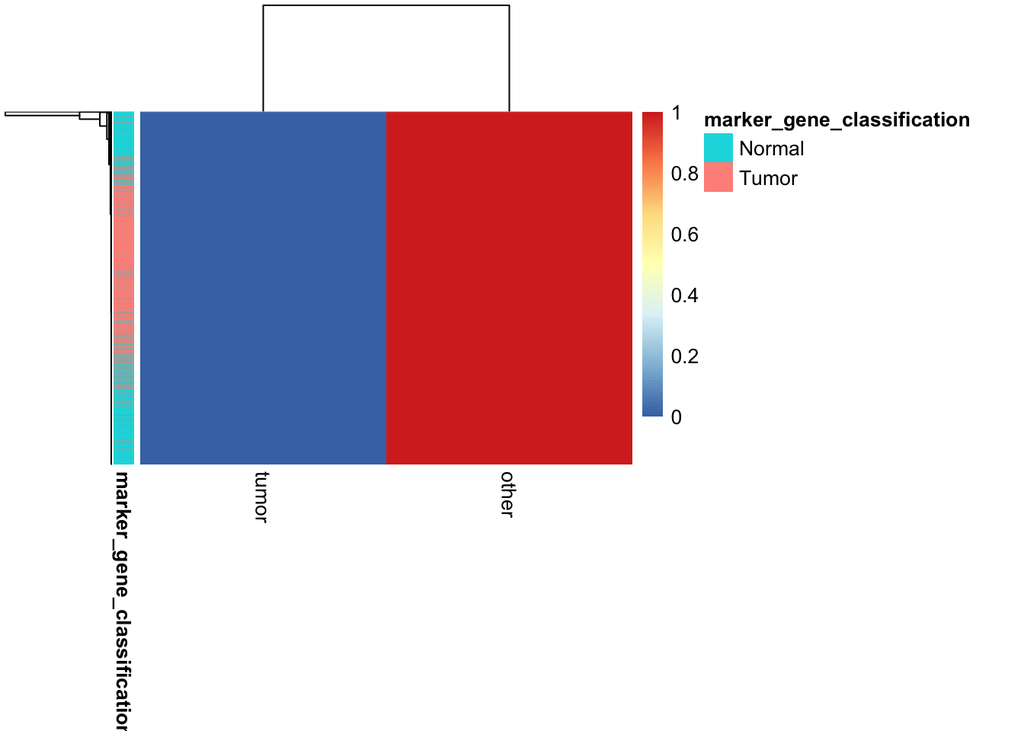

```r
# get annotations for heatmaps
annotation_df <- data.frame(
  marker_gene_classification = classifications_df$marker_gene_classification,
  row.names = classifications_df$barcodes
)

# heatmap of prediction scores
tumor_predictions |>
  tibble::column_to_rownames("barcode") |>
  as.matrix() |>
  pheatmap::pheatmap(show_rownames = FALSE,
                     annotation_row = annotation_df)
```

Looking at this, it appears that `CellAssign` is classifying all cells as “other”? I find this hard to believe since this sample was taken directly from a Ewing sarcoma tumor, so there are bound to be tumor cells.

### Run CellAssign with a filtered set of tumor marker genes

In looking at the UMAPs of all marker genes (see `01-marker-gene-tumor-classification.Rmd`) there are quite a few genes that have very low expression across all cells, so perhaps they are adding noise to the model. Although this is a bit circular, we could restrict our list of marker genes to be only those that have a high mean gene expression in our dataset? I would expect that when we do that, we are able to identify more tumor cells that line up with what we would expect based on gene expression patterns.

```r
# grab the mean gene expression for all marker genes
rowdata_df <- rowData(sce) |>
  as.data.frame() |>
  dplyr::filter(gene_symbol %in% tumor_markers_df$gene_symbol)
rowdata_df
```

```
##                        gene_ids gene_symbol      mean detected
## ENSG00000114315 ENSG00000114315        HES1 0.1603730 12.79720
## ENSG00000164647 ENSG00000164647      STEAP1 0.1743315 13.77622
## ENSG00000105974 ENSG00000105974        CAV1 2.4428347 64.28904
## ENSG00000182752 ENSG00000182752       PAPPA 2.4976345 55.12821
## ENSG00000110092 ENSG00000110092       CCND1 1.7725165 63.61305
## ENSG00000166501 ENSG00000166501       PRKCB 6.5251641 64.70862
## ENSG00000186868 ENSG00000186868        MAPT 2.4619580 56.36364
## ENSG00000119537 ENSG00000119537        KDSR 1.6605228 52.49417
## ENSG00000125820 ENSG00000125820      NKX2-2 0.8002091 38.18182
## ENSG00000002586 ENSG00000002586        CD99 1.3463039 59.20746
## ENSG00000173698 ENSG00000173698      ADGRG2 0.1808886 12.79720
## ENSG00000169297 ENSG00000169297       NR0B1 0.1311189  9.95338
```

```r
# what's the mean gene expression of all genes in this sample for reference
mean(rowData(sce)$mean)
```

```
## [1] 0.08202699
```

There are a few genes that have low gene expression < 1. Let’s try and filter out those genes and then use `CellAssign`.

```r
# get list of marker genes to keep
filtered_markers <- rowdata_df |>
  dplyr::filter(mean > 1) |>
  dplyr::pull(gene_ids)

# filter binary mtx
filtered_ref_mtx <- tumor_ref_mtx |>
  dplyr::filter(ensembl_gene_id %in% filtered_markers)

readr::write_tsv(filtered_ref_mtx, filtered_markers_mtx_file)
```

```r
cellassign_call <- glue::glue(
  "python scripts/run-cellassign.py",
  " --anndata_file '{anndata_file}'",
  " --output_predictions '{filtered_predictions_file}'",
  " --reference '{filtered_markers_mtx_file}'"
)

system(cellassign_call)
```

Now we can read in the predictions for the filtered marker gene list.

```r
filtered_predictions <- readr::read_tsv(filtered_predictions_file)
filtered_celltype_assignments <- get_celltype_assignment(filtered_predictions)

table(filtered_celltype_assignments$celltype)
```

```
##
## other tumor
##  3974   316
```

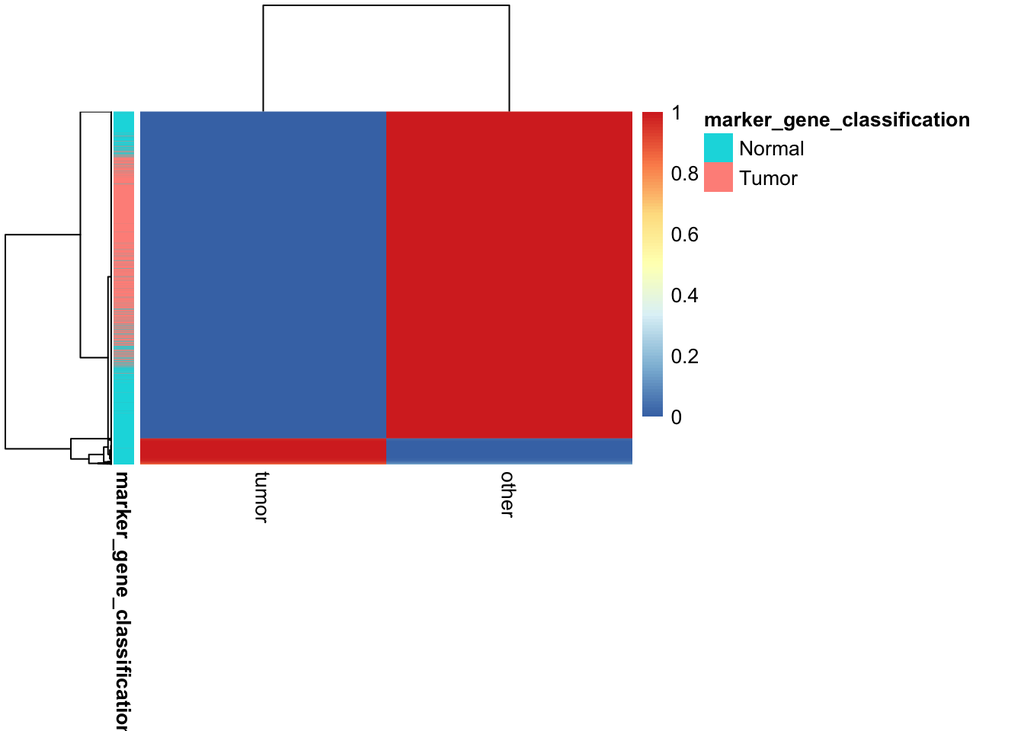

```r
# heatmap of prediction scores
filtered_predictions |>
  tibble::column_to_rownames("barcode") |>
  as.matrix() |>
  pheatmap::pheatmap(show_rownames = FALSE,
                     annotation_row = annotation_df)
```

Now we are seeing a few more tumor cells, let’s see where they are on the UMAP.

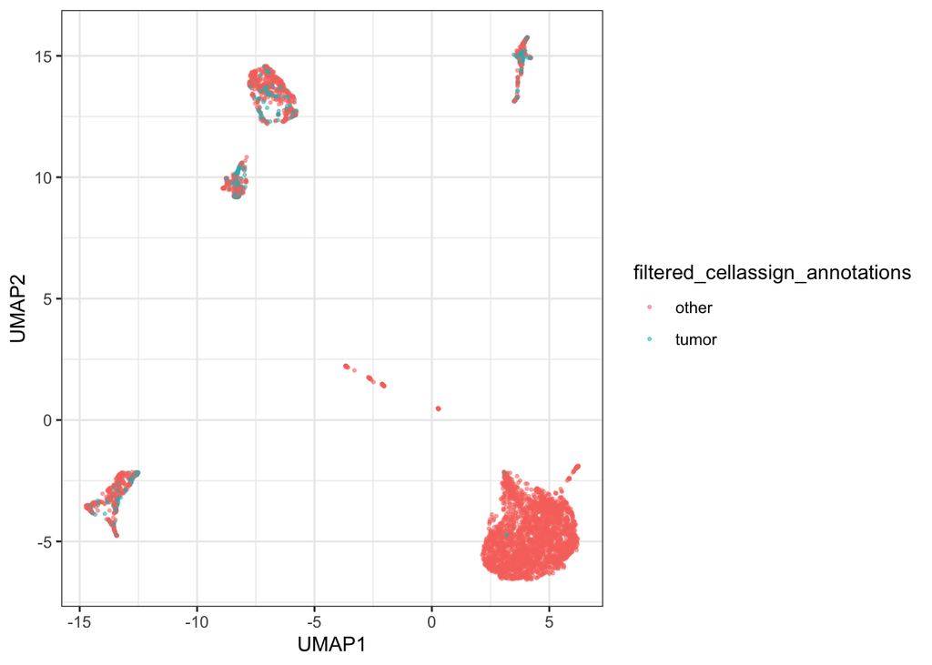

```r
filtered_celltype_assignments <- filtered_celltype_assignments |>
  dplyr::rename(filtered_cellassign_annotations = celltype)

celltype_df <- sce |>
  scuttle::makePerCellDF(use.dimred = "UMAP") |>
  # replace UMAP.1 with UMAP1
  dplyr::rename_with(
        \(x) stringr::str_replace(x, "^UMAP\\.", "UMAP")
      ) |>
  # join with tumor normal
  dplyr::left_join(classifications_df, by = "barcodes") |>
  # join with filtered cell type assignments from cellassign
  dplyr::left_join(filtered_celltype_assignments, by = c("barcodes" = "barcode"))

ggplot(celltype_df, aes(x = UMAP1, y = UMAP2, color = filtered_cellassign_annotations)) +
  geom_point(size = 0.5, alpha = 0.5) +
  theme_bw()
```

Not quite where I would expect to see tumor cells. Let’s see how many tumor cells overlap with our manual classifications using the Jaccard similarity index.

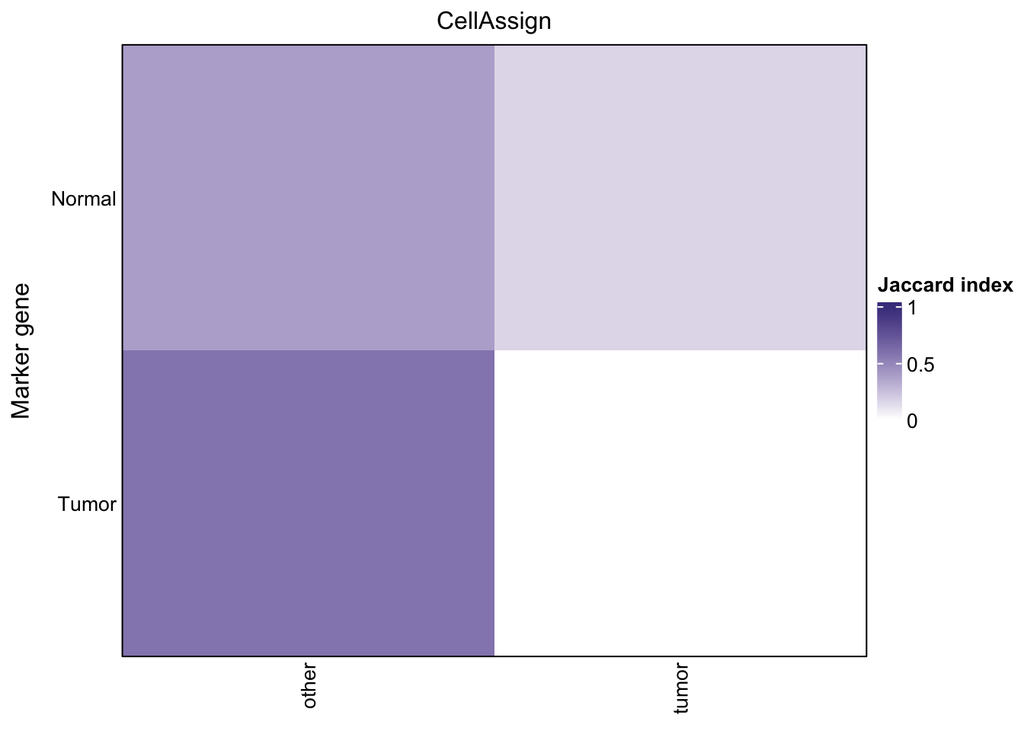

```r
jaccard_mtx <- make_jaccard_matrix(celltype_df, "filtered_cellassign_annotations", "marker_gene_classification")

ComplexHeatmap::Heatmap(
  t(jaccard_mtx), # transpose because matrix rows are in common & we want a vertical arrangement
  col = circlize::colorRamp2(c(0, 1), colors = c("white", "darkslateblue")),
  border = TRUE,
  ## Row parameters
  cluster_rows = FALSE,
  row_title = "Marker gene",
  row_title_gp = grid::gpar(fontsize = 12),
  row_title_side = "left",
  row_names_side = "left",
  row_dend_side = "right",
  row_names_gp = grid::gpar(fontsize = 10),
  ## Column parameters
  cluster_columns = FALSE,
  column_title = "CellAssign",
  column_title_gp = grid::gpar(fontsize = 12),
  column_names_side = "bottom",
  column_names_gp = grid::gpar(fontsize = 10),
  column_names_rot = 90,
  ## Legend parameters
  heatmap_legend_param = list(
    title = "Jaccard index",
    direction = "vertical",
    legend_width = unit(1.5, "in")
  ),
  show_heatmap_legend = TRUE,
)
```

Let’s look at the mean expression of marker genes between tumor and other cells as classified by `CellAssign`.

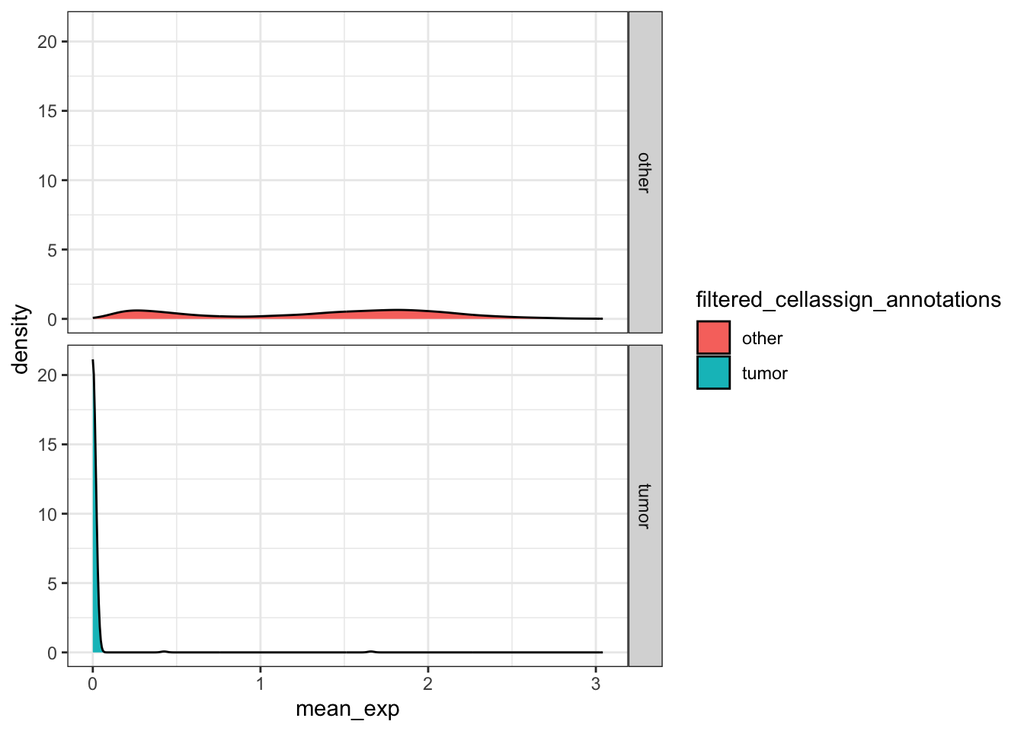

```r
# get marker gene expression
marker_gene_exp <- logcounts(sce[filtered_markers, ]) |>
  as.matrix() |>
  t() |>
  as.data.frame() |>
  tibble::rownames_to_column("barcodes")

marker_gene_exp_df <- celltype_df |>
  dplyr::left_join(marker_gene_exp, by = "barcodes") |>
  tidyr::pivot_longer(
    cols = starts_with("ENSG"),
    names_to = "ensembl_gene_id",
    values_to = "gene_expression"
  ) |>
  dplyr::group_by(barcodes) |>
  dplyr::mutate(mean_exp = mean(gene_expression))


ggplot(marker_gene_exp_df, aes(x = mean_exp, fill = filtered_cellassign_annotations)) +
  geom_density() +
  facet_grid(rows = vars(filtered_cellassign_annotations)) +
  theme_bw()
```

Unlike what I would expect, the “other” cells appear to have higher expression of marker genes? Maybe using `CellAssign` with only two options and a small set of marker genes doesn’t work in the way we would expect.

### Run CellAssign with tumor markers and all marker genes from Visser et al.

Perhaps we need to add a few more cell types, rather than just have the two options. Below we will use CellAssign but with all tumor marker genes and all marker genes in Visser et al. for non-tumor cells.

```r
# build the reference matrix
visser_ref_mtx <- build_binary_df(all_markers_df,
                                   gene_col = "ensembl_gene_id",
                                   cell_type_col = "cell_type")

# export matrix
readr::write_tsv(visser_ref_mtx, visser_markers_mtx_file)
```

```r
cellassign_call <- glue::glue(
  "python scripts/run-cellassign.py",
  " --anndata_file '{anndata_file}'",
  " --output_predictions '{visser_predictions_file}'",
  " --reference '{visser_markers_mtx_file}'"
)

system(cellassign_call)
```

```r
# read in predictions and get cell type assignments
visser_predictions <- readr::read_tsv(visser_predictions_file)
visser_celltype_assignments <- get_celltype_assignment(visser_predictions)

table(visser_celltype_assignments$celltype)
```

```
##
##      endothelial cells                 immune mesenchymal-like cells                  tumor
##                   3224                    457                    340                    269
```

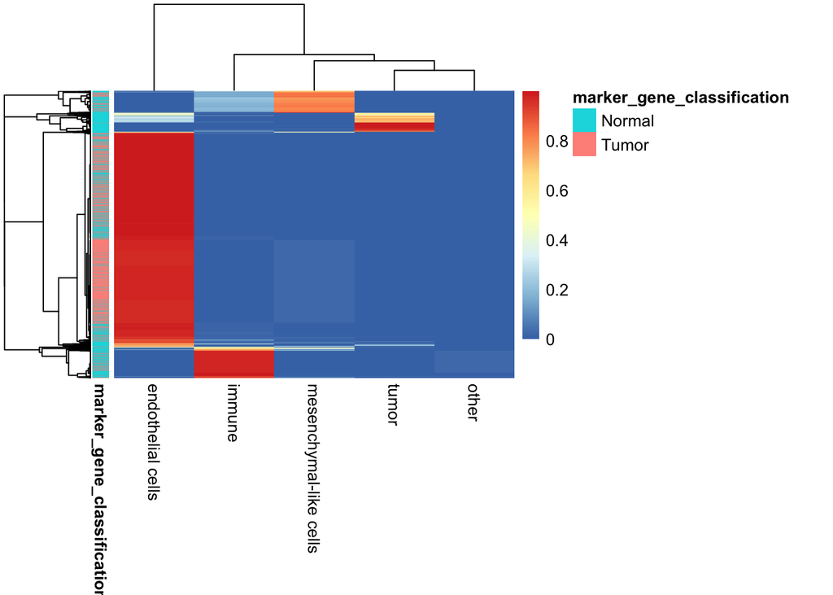

```r
# heatmap of prediction scores
visser_predictions |>
  tibble::column_to_rownames("barcode") |>
  as.matrix() |>
  pheatmap::pheatmap(show_rownames = FALSE,
                     annotation_row = annotation_df)
```

Here we see that there are still only a few hundred tumor cells and most cells are endothelial cells. Generally, I expect that there to be a large portion of tumor cells with much fewer cells from normal cell types.

Below we will look at which cells are assigned to which cell type and then compare assignments between CellAssign and manual marker gene assignment.

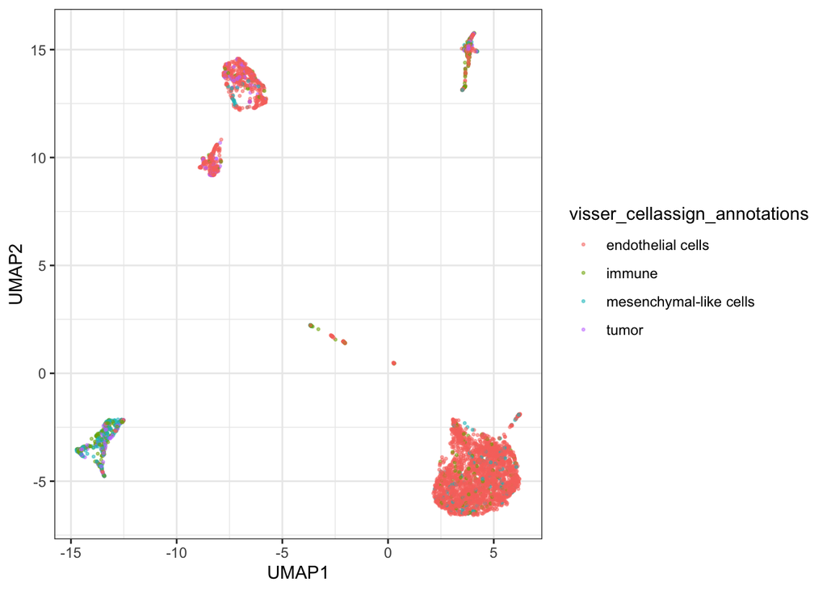

```r
# first rename column to combine with cell type df
visser_celltype_assignments <- visser_celltype_assignments |>
  dplyr::rename(visser_cellassign_annotations = celltype)

celltype_df <- celltype_df |>
  dplyr::left_join(visser_celltype_assignments, by = c("barcodes" = "barcode"))

# umap showing cell type annotations from using Visser reference
ggplot(celltype_df, aes(x = UMAP1, UMAP2, color = visser_cellassign_annotations)) +
  geom_point(size = 0.5, alpha = 0.5) +
  theme_bw()
```

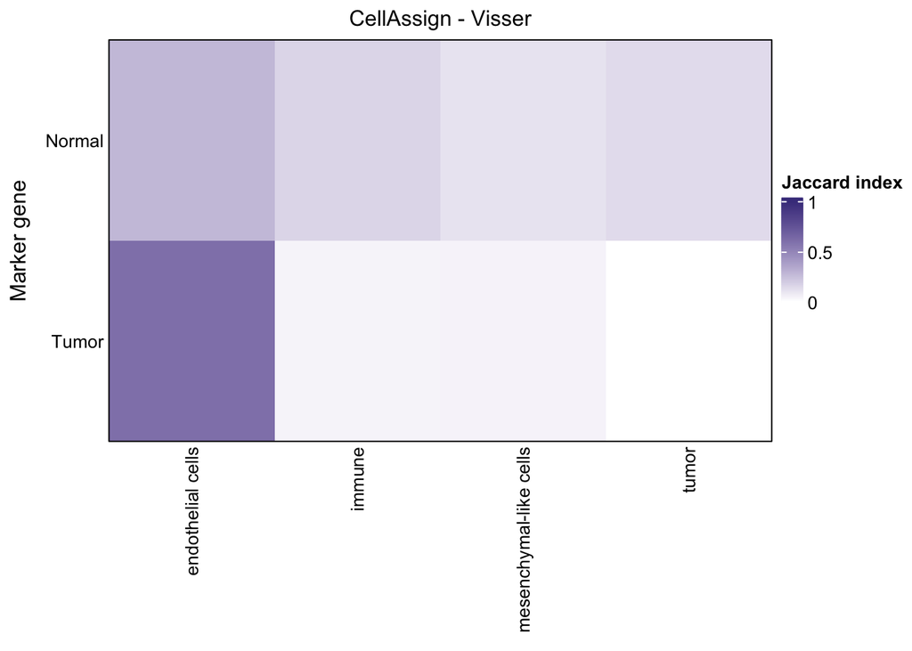

```r
# get jaccard similarity index
jaccard_mtx <- make_jaccard_matrix(celltype_df, "visser_cellassign_annotations", "marker_gene_classification")

ComplexHeatmap::Heatmap(
  t(jaccard_mtx), # transpose because matrix rows are in common & we want a vertical arrangement
  col = circlize::colorRamp2(c(0, 1), colors = c("white", "darkslateblue")),
  border = TRUE,
  ## Row parameters
  cluster_rows = FALSE,
  row_title = "Marker gene",
  row_title_gp = grid::gpar(fontsize = 12),
  row_title_side = "left",
  row_names_side = "left",
  row_dend_side = "right",
  row_names_gp = grid::gpar(fontsize = 10),
  ## Column parameters
  cluster_columns = FALSE,
  column_title = "CellAssign - Visser",
  column_title_gp = grid::gpar(fontsize = 12),
  column_names_side = "bottom",
  column_names_gp = grid::gpar(fontsize = 10),
  column_names_rot = 90,
  ## Legend parameters
  heatmap_legend_param = list(
    title = "Jaccard index",
    direction = "vertical",
    legend_width = unit(1.5, "in")
  ),
  show_heatmap_legend = TRUE,
)
```

Again, we don’t see much overlap of cells that we are classifying as tumor manually to the tumor cells being classified by CellAssign. We do see that the majority of the immune and mesenchymal-like cells fall into the “normal” category, but this isn’t the case for endothelial cells.

Below, we look at the individual expression of each marker genes in the cells. These plots are grouped to show all marker genes for a given cell type in a single panel.

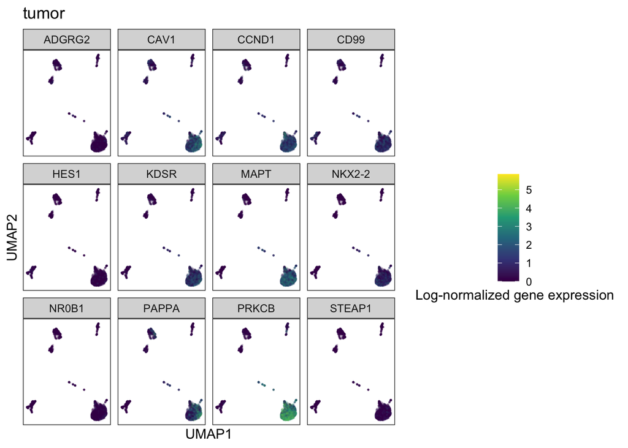

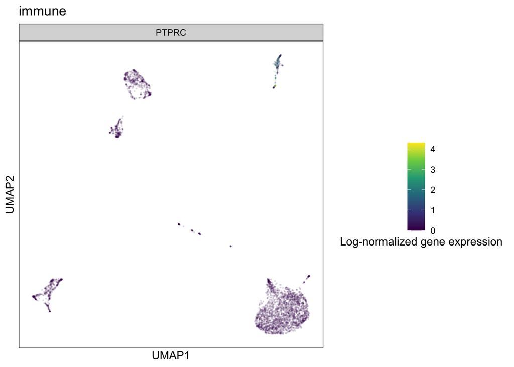

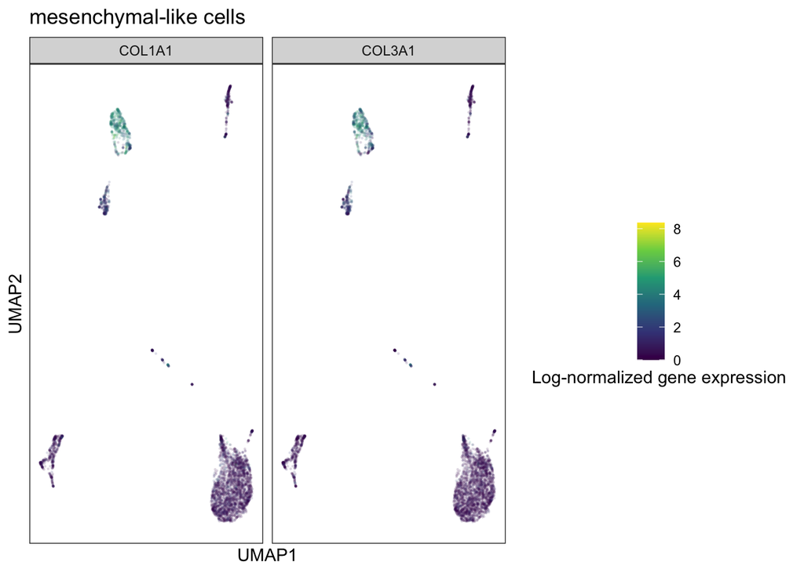

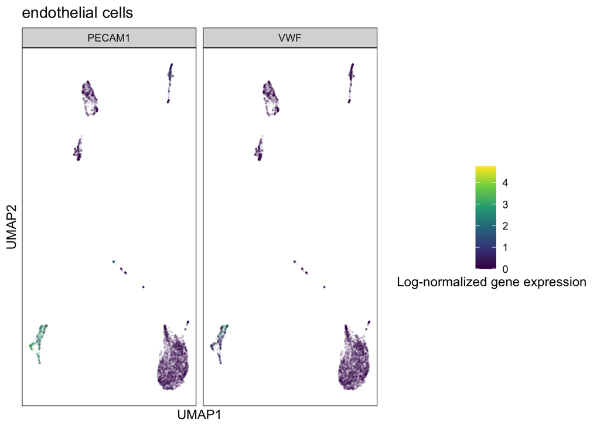

```r
# get all markers
all_markers <- all_markers_df |>
  dplyr::pull(ensembl_gene_id)

# get expression for all markers
marker_gene_exp <- logcounts(sce[all_markers, ]) |>
  as.matrix() |>
  t() |>
  as.data.frame() |>
  tibble::rownames_to_column("barcodes")

# add in gene expression to cell type df for plotting
marker_gene_exp_df <- celltype_df |>
  dplyr::left_join(marker_gene_exp, by = "barcodes") |>
  tidyr::pivot_longer(
    cols = starts_with("ENSG"),
    names_to = "ensembl_gene_id",
    values_to = "gene_expression"
  ) |>
  dplyr::left_join(all_markers_df)
# get a list of all celltypes in the reference
celltypes <- unique(all_markers_df$cell_type)

# for each cell type, plot each individual marker as a UMAP
celltypes |>
  purrr::map(\(celltype){
    plot_df <- marker_gene_exp_df |>
      dplyr::filter(cell_type == celltype)

    # faceted umap showing a umap panel for each marker gene
    ggplot(plot_df, aes(x = UMAP1, y = UMAP2, color = gene_expression)) +
      geom_point(alpha = 0.1, size = 0.2) +
      facet_wrap(vars(gene_symbol)) +
      scale_color_viridis_c() +
      labs(
        title = celltype,
        color = "Log-normalized gene expression"
      ) +
      # remove axis numbers and background grid
      scale_x_continuous(labels = NULL, breaks = NULL) +
      scale_y_continuous(labels = NULL, breaks = NULL) +
      theme(
        aspect.ratio = 1,
        legend.position = "bottom",
        axis.title = element_text(size = 9, color = "black"),
        strip.text = element_text(size = 8),
        legend.title = element_text(size = 9),
        legend.text = element_text(size = 8)
      ) +
      guides(colour = guide_colorbar(title.position = "bottom", title.hjust = 0.5)) +
      theme_bw()

  })
```

Interestingly, the endothelial and MSC like markers seem to be localized to a small group of cells, where as CellAssign assigns most cells to endothelial cells.

Below we look at the expression of marker genes for each cell type across all cells identified to be each type by CellAssign. We would expect to see expression of the marker genes for tumor cells to be higher in the cells that are identified to be tumor cells compared to other cell types.

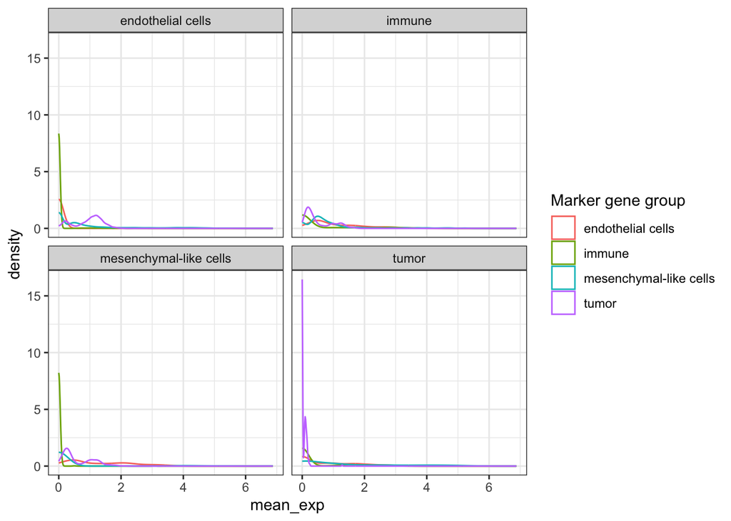

```r
grouped_celltype_df <- marker_gene_exp_df |>
  # group by barcode and cell type to get the sum
  dplyr::group_by(barcodes, cell_type) |>
  dplyr::mutate(mean_exp = mean(gene_expression))

ggplot(grouped_celltype_df, aes(x = mean_exp, color = cell_type)) +
  geom_density() +
  facet_wrap(vars(visser_cellassign_annotations)) +
  theme_bw() +
  labs(
    color = "Marker gene group"
  )
```

It looks like the only real difference between groups is that the endothelial cells have higher expression of the tumor markers then other cells? However the tumor cells do not show increased expression of the tumor marker genes. This really is not what I would expect… maybe we need a larger reference…

### Run CellAssign with markers from PanglaoDB

The last thing I’m trying here is to run CellAssign using some of the same reference that we used when running CellAssign as part of scpca-nf. In particular, the majority of non-muscle cells (which we believe to be tumor cells) were identified as either Endothelial cells or Fibroblasts. So we will create a reference that takes the markers for Endothelial cells and Fibroblasts from PanglaoDB and combines with the tumor markers.

```r
# get just the genes for endothelial and fibroblasts from panglao
panglao_markers_df <- readr::read_tsv(panglao_markers_file) |>
  dplyr::filter(`cell type` %in% c("Endothelial cells", "Fibroblasts")) |>
  dplyr::select(`official gene symbol`, `cell type`)
# get the ensembl id from rowdata for each panglao marker
panglao_tumor_markers_df <- rowData(sce) |>
  as.data.frame() |>
  dplyr::filter(gene_symbol %in% panglao_markers_df$`official gene symbol`) |>
  dplyr::left_join(panglao_markers_df, by = c("gene_symbol" = "official gene symbol")) |>
  dplyr::select(gene_symbol, ensembl_gene_id = gene_ids, cell_type = `cell type`) |>
  # add in the tumor markers
  dplyr::bind_rows(tumor_markers_df)
# build the reference matrix
panglao_tumor_ref_mtx <- build_binary_df(panglao_tumor_markers_df,
                                          gene_col = "ensembl_gene_id",
                                          cell_type_col = "cell_type")

# remove any genes that may be present in multiple cell types
rowsums <- panglao_tumor_ref_mtx |>
  dplyr::select(-ensembl_gene_id) |>
  rowSums()

panglao_tumor_ref_mtx <- panglao_tumor_ref_mtx[-which(rowsums > 1),]

# export matrix
readr::write_tsv(panglao_tumor_ref_mtx, panglao_markers_mtx_file)
```

```r
cellassign_call <- glue::glue(
  "python scripts/run-cellassign.py",
  " --anndata_file '{anndata_file}'",
  " --output_predictions '{panglao_predictions_file}'",
  " --reference '{panglao_markers_mtx_file}'"
)

system(cellassign_call)
```

```r
# read in predictions file
panglao_predictions <- readr::read_tsv(panglao_predictions_file)
# get cell type assignments
panglao_celltype_assignments <- get_celltype_assignment(panglao_predictions)

# create a table of assignments
table(panglao_celltype_assignments$celltype)
```

```
##
## Endothelial cells             other             tumor
##                 1              3942               347
```

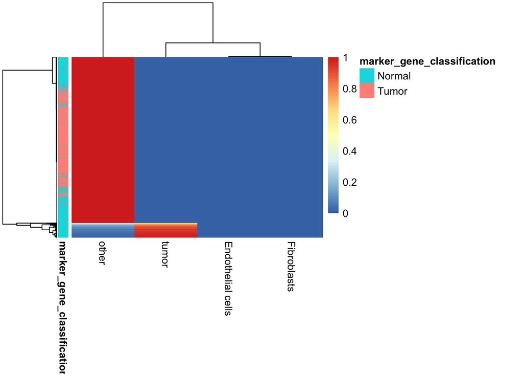

```r
# heatmap of prediction scores
panglao_predictions |>
  tibble::column_to_rownames("barcode") |>
  as.matrix() |>
  pheatmap::pheatmap(show_rownames = FALSE,
                     annotation_row = annotation_df)
```

This is definitely not what I expected… It looks like most cells are categorized as “other” with a few categorized as tumor and only 1 endothlial cell. I would have thought that at least some cells would be endothelial or fibroblast.

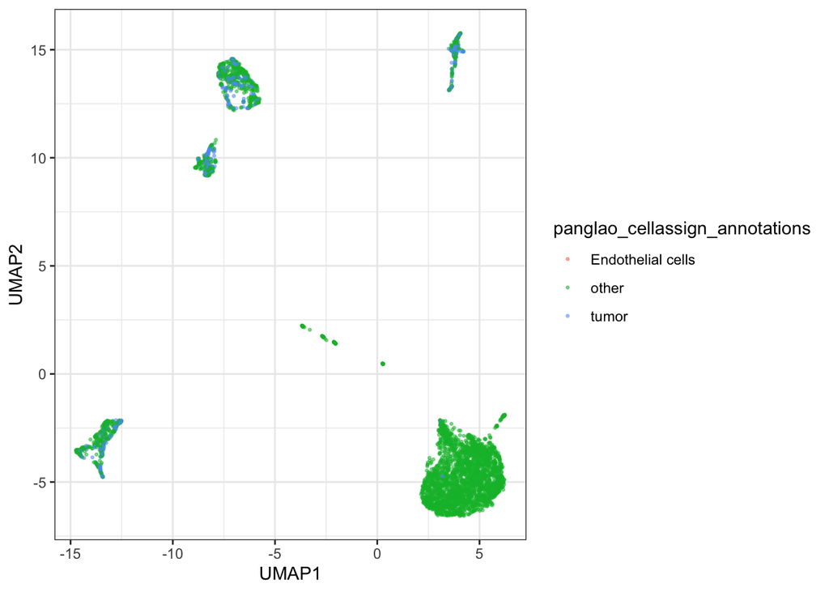

```r
# first rename column to combine with cell type df
panglao_celltype_assignments <- panglao_celltype_assignments |>
  dplyr::rename(panglao_cellassign_annotations = celltype)

celltype_df <- celltype_df |>
  dplyr::left_join(panglao_celltype_assignments, by = c("barcodes" = "barcode"))

# umap showing cell type annotations from using Visser reference
ggplot(celltype_df, aes(x = UMAP1, UMAP2, color = panglao_cellassign_annotations)) +
  geom_point(size = 0.5, alpha = 0.5) +
  theme_bw()
```

## Conclusions

- Using `CellAssign` with the same list of marker genes doesn’t identify any tumor cells.
- Using `CellAssign` with a restricted list of marker genes identfies tumor cells that have lower marker gene expression than other cells. This is opposite of the assignment we obtained using manual annotation.
- Using `CellAssign` with an expanded list of marker genes from Visser et al., identifies all cell types, but the majority are endothelial cells. This doesn’t match up with what’s expected based on marker gene expression in the sample.
- Using `CellAssign` with the Panglao markers and tumor markers identifies mostly normal cells and very few tumor cells. Again, the cells labeled as tumor cells are opposite of the manual annotation.